# FetalBrain - Summary

#### Overlapping UMRs with TFBSs show asymmetric in Brain and Cortex

- Overlap UMRs with transcription factor binding sites and count No. of overlapping TFBSs for each TF showed similar asymmetry in Brain and Cortex, but is symmetric in GE. The correlation between Brain and Cortex is also very low, **0.15**.
- With 2-fold change cutoff, there are 18 TFs enriched in HuFNSC02 in both Brain and Cortex.

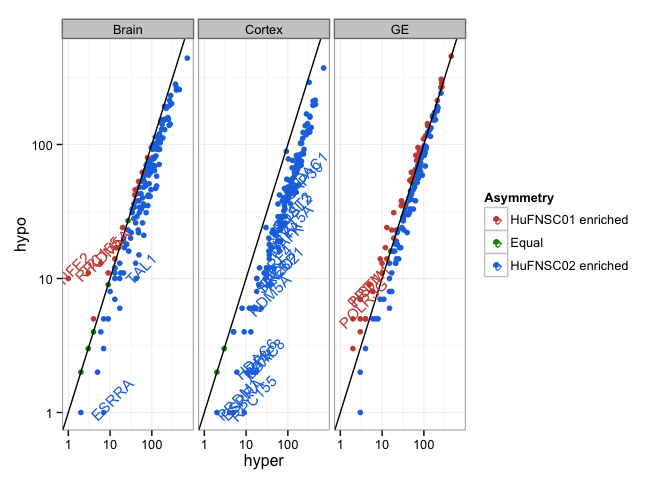

| TF | Brain.hypo | Brain.hyper | Ratio.Brain | Cortex.hypo | Cortex.hyper | Ratio.Cortex |
| --- | --- | --- | --- | --- | --- | --- |
| ESRRA | 1 | 7 | 0.14 | 1 | 5 | 0.20 |
| TAL1 | 10 | 42 | 0.24 | 9 | 34 | 0.26 |
| HNF4A | 15 | 49 | 0.31 | 11 | 27 | 0.41 |
| HNF4G | 13 | 41 | 0.32 | 10 | 29 | 0.34 |
| ZNF217 | 6 | 17 | 0.35 | 6 | 14 | 0.43 |
| EBF1 | 49 | 130 | 0.38 | 48 | 98 | 0.49 |
| FOS | 47 | 123 | 0.38 | 43 | 118 | 0.36 |
| GATA1 | 31 | 73 | 0.42 | 32 | 80 | 0.40 |
| HSF1 | 3 | 7 | 0.43 | 2 | 6 | 0.33 |
| FOXA2 | 26 | 60 | 0.43 | 14 | 36 | 0.39 |
| GATA3 | 35 | 80 | 0.44 | 22 | 52 | 0.42 |
| GATA2 | 58 | 130 | 0.45 | 39 | 96 | 0.41 |
| STAT3 | 41 | 91 | 0.45 | 26 | 87 | 0.30 |
| CEBPD | 22 | 48 | 0.46 | 23 | 64 | 0.36 |
| SMC3 | 71 | 150 | 0.47 | 62 | 144 | 0.43 |
| NR3C1 | 46 | 95 | 0.48 | 39 | 90 | 0.43 |
| RXRA | 23 | 47 | 0.49 | 16 | 35 | 0.46 |
| HDAC6 | 1 | 2 | 0.50 | 2 | 11 | 0.18 |

#### DE genes are cell type specific

|  | UP | DN | DE |
| --- | --- | --- | --- |
| brain01_brain02 | 461 | 181 | 642 |
| cortex01_cortex02 | 248 | 348 | 596 |
| GE01_GE02 | 99 | 74 | 173 |

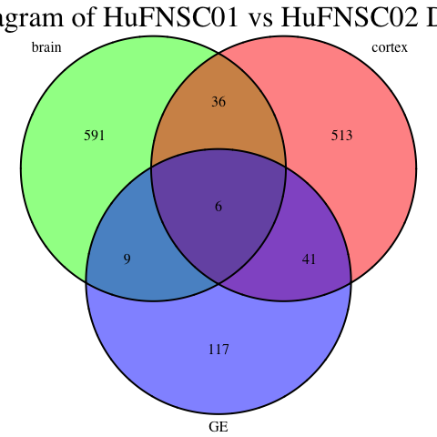

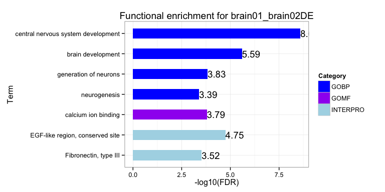

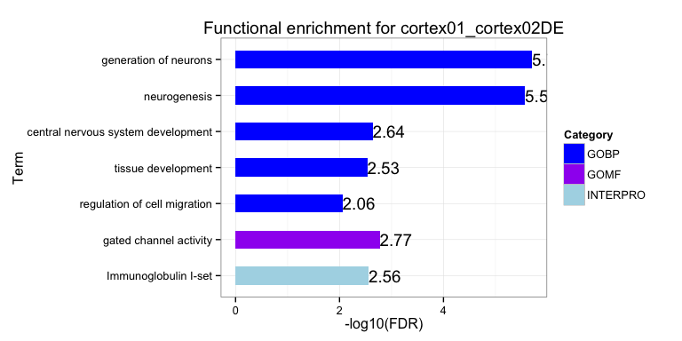

| name | description | Brain | Cortex | GE |
| --- | --- | --- | --- | --- |
| LMO1 | LIM_domain_only_1_(rhombotin_1) | UP | DN | DN |
| CXCR7 | chemokine_(C-X-C_motif)*receptor*7 | UP | UP | DN |
| SPP1 | secreted_phosphoprotein_1 | UP | DN | DN |
| NPY | neuropeptide_Y | UP | DN | DN |
| COL2A1 | collagen,*type*II,*alpha*1 | DN | UP | UP |
| BCL6 | B-cell_CLL/lymphoma_6 | DN | DN | DN |

#### Isoforms between MZ are enriched in cell signaling in neurospheres and immune response in Brain

|  | DE_genes | DE_exons | with_expressed_genes | isoform_exons | exclude_DE_genes | isoform_genes |
| --- | --- | --- | --- | --- | --- | --- |
| brain01_brain02_summary | 642 | 32138 | 16302 | 8980 | 8542 | 2902 |
| cortex01_cortex02_summary | 596 | 26983 | 15554 | 7618 | 7445 | 2454 |
| GE01_GE02_summary | 173 | 23810 | 12862 | 7402 | 7351 | 2495 |
| cortex03_cortex04_summary | 642 | 26826 | 12185 | 5818 | 5479 | 1994 |
| GE03_GE04_summary | 545 | 24752 | 12223 | 4582 | 4422 | 1454 |

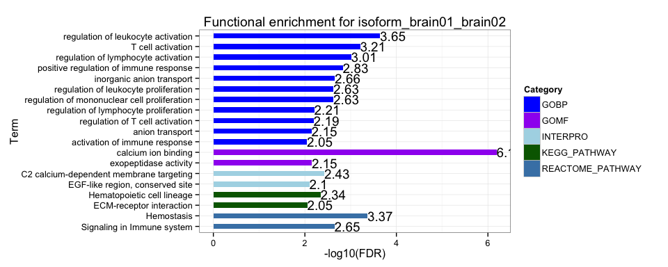

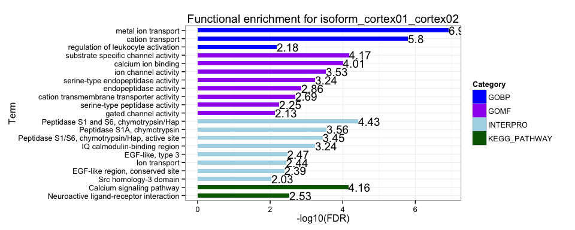

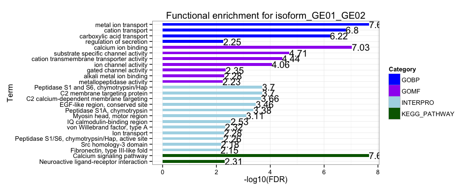

## Methods

### DMR identification

#### WGBS

- Identify DM CpGs
  - methyl_diff one-sided p-value $\le$ 0.005
  - delta fractional methylation $\ge$ 0.5
  - fractional methylation of one sample $\ge$ 0.75
- Collapse DM CpGs into DMRs
  - adjacent DM CpGs have the same DM status;
  - distance between adjacent CpGs (size) $\le$ 300bp;
  - No. of CpGs within each DMR $\ge$ 3.

#### MeDIP

- DM CpG identification:
  - delta fractional methylation $\ge$ 0.6
  - fractional methylation of one sample $\ge$ 0.75
- Collapse DM CpGs into DMRs:
  - adjacent CpGs have the same DM status;
  - distance between adjacent CpGs $\le$ 300bp;
  - No. of CpGs within each DMR $\ge$ 4.

### Differential gene expression with DEfine

- FDR = 0.01
- Minimum sum of RPKM (rmin) = 0.005
- Minimum sum of coverage (Nmin) = 25

### Isoform identification and junction validation

- DEfine on exons: FDR = 0.01
- Exon expressed in one sample ($\ge$ 10% gene RPKM) and not expressed in the other ($\le$ 1% gene RPKM)
- Gene is not DE: DEfine FDR = 0.01
- Gene is expressed in both samples: gene RPKM > 0.01
- Validation: For each isoform exon in the previous pairwise comparison
  - Find junctions associated with this exon with enough coverage, i.e. sum of junction coverage of two samples $\ge$ 1
  - Identify junctions that RPKM change in the same direction as the exon
  - Junction RPKM > 0.1 in one sample and < 0.1 in the other